# STA6856 Time Series

SARIMA modeling

Author

Hector Gavilanes

```r
# libraries
library(itsmr)
library(car)      #power transformation
library(aTSA)
library(forecast)
```

Fit SARIMA(p,d,q)x(P,D,Q) models to the following time series data:

1. `airpass`
2. `wine`

Post your work (HTML) on Canvas discussion board.

## Airpass

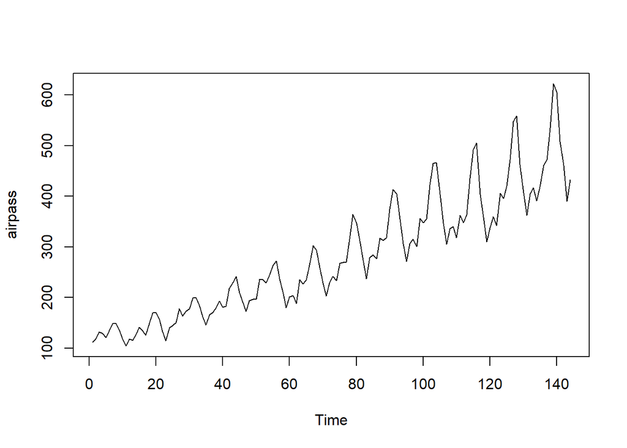

```r
# plot
plot.ts(airpass)
```

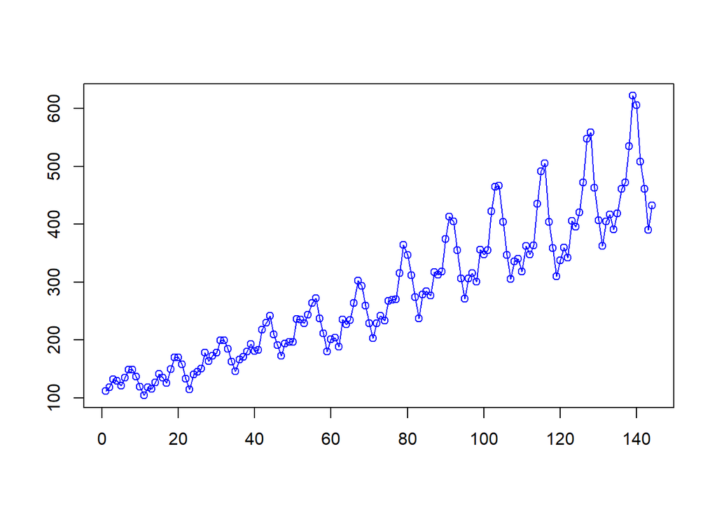

```r
plotc(airpass)
```

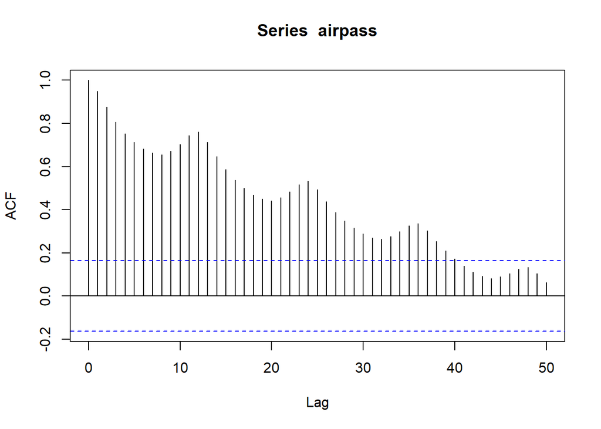

```r
# ACF, PACF
acf(airpass, lag.max = 50)
```

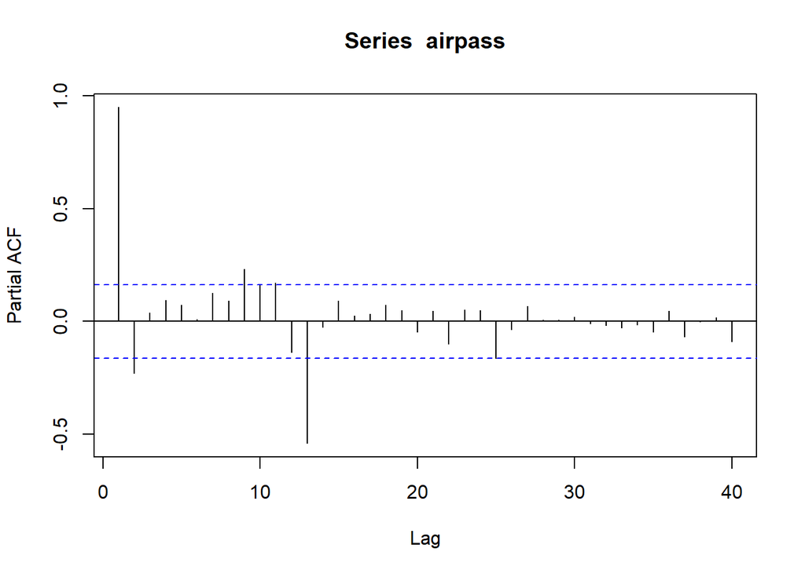

```r
pacf(airpass, lag.max = 40)
```

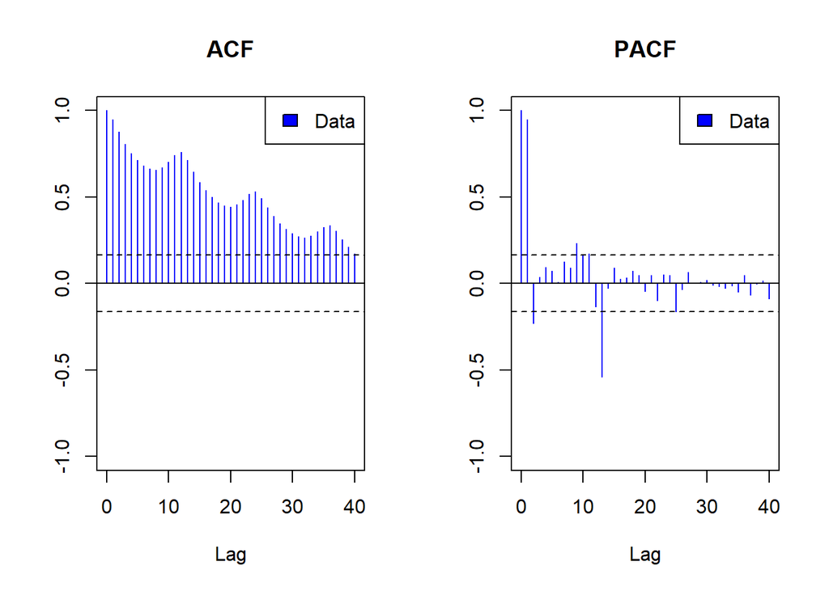

```r
plota(airpass)
```

## Power Transformation

```r
# Variance change transformation
lambda = powerTransform(airpass)
lambda$roundlam
```

```
airpass
      0
```

Lambda $\lambda$=0; thus, we can apply Log Power Transformation.

## Differencing Operator

By Elimination, we have the following:

$$y_t = \nabla^1 \nabla_{12} +Y_t$$

```
Null hypothesis: Residuals are iid noise.
Test                        Distribution Statistic   p-value
Ljung-Box Q                Q ~ chisq(20)      64.6         0 *
McLeod-Li Q                Q ~ chisq(20)      48.2     4e-04 *
Turning points T     (T-86)/4.8 ~ N(0,1)        97    0.0217 *
Diff signs S         (S-65)/3.3 ~ N(0,1)        62    0.3657
Rank P         (P-4257.5)/251.3 ~ N(0,1)      4115    0.5707
```

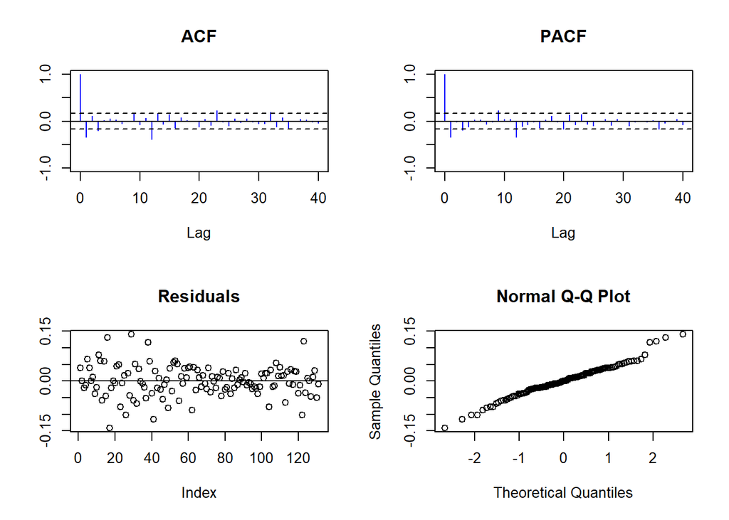

```r
# Eliminate components using Differencing Operator
air_diff = c("log", "diff", 12, "diff", 1)
r_diff = Resid(airpass, air_diff)
test(r_diff)
```

Reject the IID null hypothesis.

## Test Stationary

```r
adf.test(r_diff)
```

```
Augmented Dickey-Fuller Test
alternative: stationary

Type 1: no drift no trend
     lag    ADF p.value
[1,]   0 -16.25    0.01
[2,]   1  -9.34    0.01
[3,]   2  -8.65    0.01
[4,]   3  -7.70    0.01
[5,]   4  -6.10    0.01
Type 2: with drift no trend
     lag    ADF p.value
[1,]   0 -16.19    0.01
[2,]   1  -9.30    0.01
[3,]   2  -8.61    0.01
[4,]   3  -7.67    0.01
[5,]   4  -6.08    0.01
Type 3: with drift and trend
     lag    ADF p.value
[1,]   0 -16.16    0.01
[2,]   1  -9.29    0.01
[3,]   2  -8.62    0.01
[4,]   3  -7.70    0.01
[5,]   4  -6.09    0.01
----
Note: in fact, p.value = 0.01 means p.value <= 0.01
```

## SARIMA Model

### Based on the PACF

p = 0,1,2,9,10,11,13

P = 0,1,2

### Based on the ACF

q = 0:40

Q = 0,1,2,3

### Eliminate Trend and Season

d= 1

D = 1

```
Null hypothesis: Residuals are iid noise.
Test                        Distribution Statistic   p-value
Ljung-Box Q                Q ~ chisq(20)     22.87    0.2951
McLeod-Li Q                Q ~ chisq(20)     31.15    0.0532
Turning points T     (T-94.7)/5 ~ N(0,1)        91    0.4658
Diff signs S       (S-71.5)/3.5 ~ N(0,1)        69     0.472
Rank P           (P-5148)/289.5 ~ N(0,1)      4919    0.4289
```

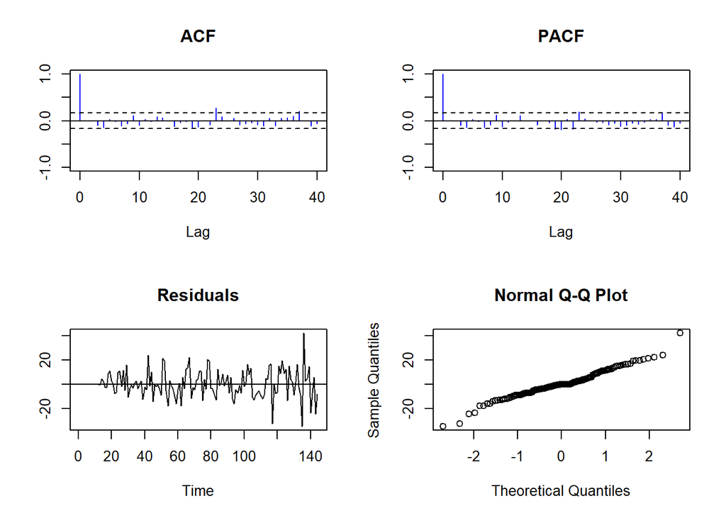

```r
# SARIMA (1,1,1)x(1,1,1)12
fit1 = arima(airpass,
             order = c(1,1,1),
             seasonal = list(order=c(1,1,1), period=12))
test(fit1$residuals)
```

```r
confint(fit1)
```

```
          2.5 %     97.5 %
ar1  -1.2873694  1.0098740
ma1  -1.4028329  0.9974509
sar1 -1.3904416 -0.4550948
sma1  0.1432754  1.5226083
```

### Auto-fit

```r
# Auto fit
bestmodel = auto.arima(airpass, trace = T, seasonal = T)
```

```
 ARIMA(2,1,2) with drift         : Inf
 ARIMA(0,1,0) with drift         : 1415.363
 ARIMA(1,1,0) with drift         : 1403.646
 ARIMA(0,1,1) with drift         : 1399
 ARIMA(0,1,0)                    : 1413.937
 ARIMA(1,1,1) with drift         : 1396.411
 ARIMA(2,1,1) with drift         : Inf
 ARIMA(1,1,2) with drift         : Inf
 ARIMA(0,1,2) with drift         : 1398.675
 ARIMA(2,1,0) with drift         : 1398.265
 ARIMA(1,1,1)                    : 1394.856
 ARIMA(0,1,1)                    : 1397.344
 ARIMA(1,1,0)                    : 1401.938
 ARIMA(2,1,1)                    : 1378.628
 ARIMA(2,1,0)                    : 1396.76
 ARIMA(3,1,1)                    : 1380.052
 ARIMA(2,1,2)                    : 1387.847
 ARIMA(1,1,2)                    : 1385.787
 ARIMA(3,1,0)                    : 1395.311
 ARIMA(3,1,2)                    : 1377.704
 ARIMA(4,1,2)                    : 1374.39
 ARIMA(4,1,1)                    : 1384.672
 ARIMA(5,1,2)                    : 1376.429
 ARIMA(4,1,3)                    : Inf
 ARIMA(3,1,3)                    : Inf
 ARIMA(5,1,1)                    : 1386.205
 ARIMA(5,1,3)                    : Inf
 ARIMA(4,1,2) with drift         : 1357.225
 ARIMA(3,1,2) with drift         : Inf
 ARIMA(4,1,1) with drift         : 1385.641
 ARIMA(5,1,2) with drift         : Inf
 ARIMA(4,1,3) with drift         : Inf
 ARIMA(3,1,1) with drift         : Inf
 ARIMA(3,1,3) with drift         : Inf
 ARIMA(5,1,1) with drift         : 1386.95
 ARIMA(5,1,3) with drift         : Inf

 Best model: ARIMA(4,1,2) with drift
```

```
Null hypothesis: Residuals are iid noise.
Test                        Distribution Statistic   p-value
Ljung-Box Q                Q ~ chisq(20)    108.39         0 *
McLeod-Li Q                Q ~ chisq(20)    123.69         0 *
Turning points T     (T-94.7)/5 ~ N(0,1)        94    0.8945
Diff signs S       (S-71.5)/3.5 ~ N(0,1)        72    0.8856
Rank P           (P-5148)/289.5 ~ N(0,1)      5308    0.5805
```

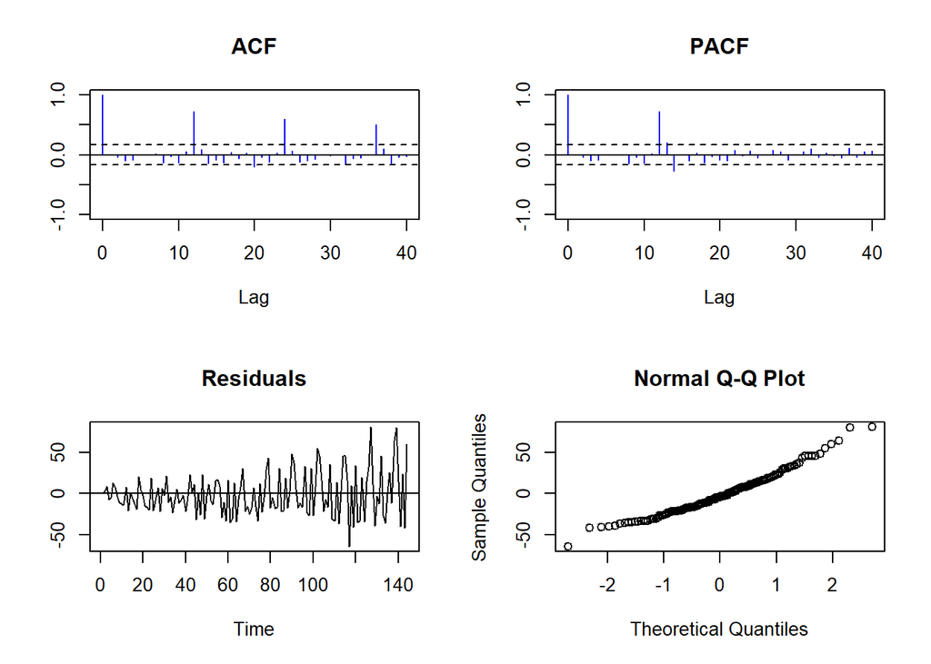

```r
test(bestmodel$residuals)
```

Using the best model (4,1,2) to remove seasonality for stationary models.

```
Null hypothesis: Residuals are iid noise.
Test                        Distribution Statistic   p-value
Ljung-Box Q                Q ~ chisq(20)     20.73    0.4132
McLeod-Li Q                Q ~ chisq(20)     24.03    0.2409
Turning points T     (T-94.7)/5 ~ N(0,1)        85    0.0545
Diff signs S       (S-71.5)/3.5 ~ N(0,1)        72    0.8856
Rank P           (P-5148)/289.5 ~ N(0,1)      5121    0.9257
```

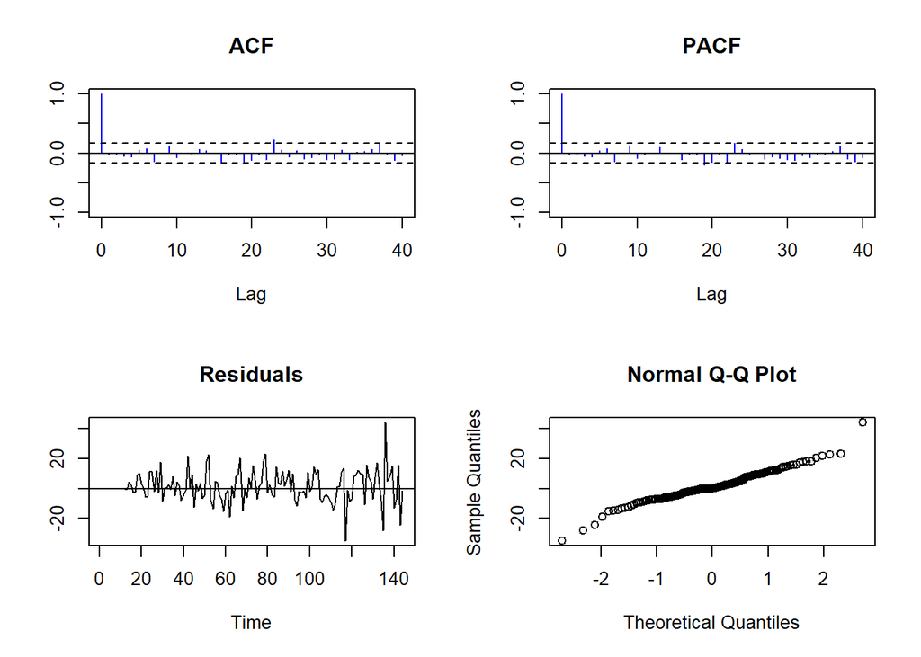

```r
# SARIMA (4,1,2)x(1,1,1)12
fit2 = arima(airpass,
             order = c(4,1,2),
             seasonal = list(order=c(1,1,1), period=12))
test(fit2$residuals)
```

```r
confint(fit2)
```

```
           2.5 %      97.5 %
ar1  -0.53333261 -0.18018465
ar2   0.62131930  1.01195104
ar3   0.03938686  0.41787611
ar4  -0.29136042  0.07100805
ma1  -0.07298772  0.12581602
ma2  -1.07128261 -0.87586009
sar1 -1.42245369 -0.31567143
sma1  0.05698405  1.48566996
```

Failed to reject the null hypothesis. The model is stationary.

```
Null hypothesis: Residuals are iid noise.
Test                        Distribution Statistic   p-value
Ljung-Box Q                Q ~ chisq(20)      22.6    0.3091
McLeod-Li Q                Q ~ chisq(20)     29.41      0.08
Turning points T     (T-94.7)/5 ~ N(0,1)        91    0.4658
Diff signs S       (S-71.5)/3.5 ~ N(0,1)        71    0.8856
Rank P           (P-5148)/289.5 ~ N(0,1)      5105    0.8819
```

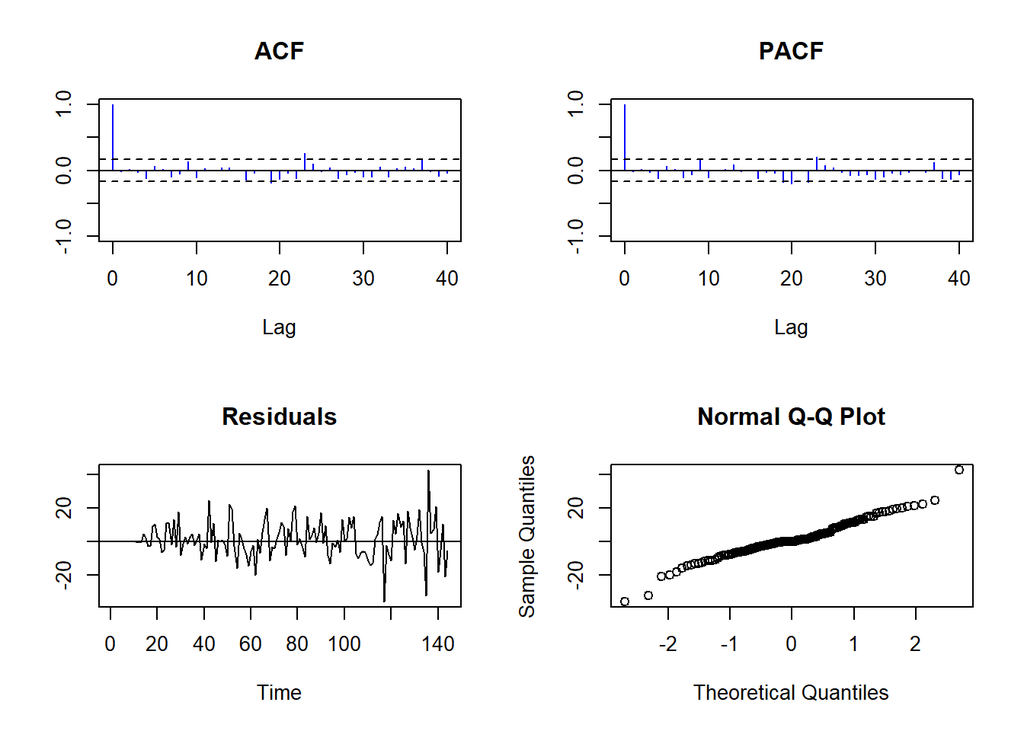

```r
# SARIMA (2,1,2)x(1,1,0)12
fit3 = arima(airpass,
             order = c(2,1,2),
             seasonal = list(order=c(1,1,0), period=12))
test(fit3$residuals)
```

```r
confint(fit3)
```

```
           2.5 %      97.5 %
ar1  -0.16611147  0.98744354
ar2  -0.08539515  0.77254206
ma1  -1.37195955 -0.18594126
ma2  -0.76157857  0.37872759
sar1 -0.32794944  0.06257939
```

```
Null hypothesis: Residuals are iid noise.
Test                        Distribution Statistic   p-value
Ljung-Box Q                Q ~ chisq(20)     20.73    0.4134
McLeod-Li Q                Q ~ chisq(20)     24.12    0.2373
Turning points T     (T-94.7)/5 ~ N(0,1)        85    0.0545
Diff signs S       (S-71.5)/3.5 ~ N(0,1)        72    0.8856
Rank P           (P-5148)/289.5 ~ N(0,1)      5129    0.9477
```

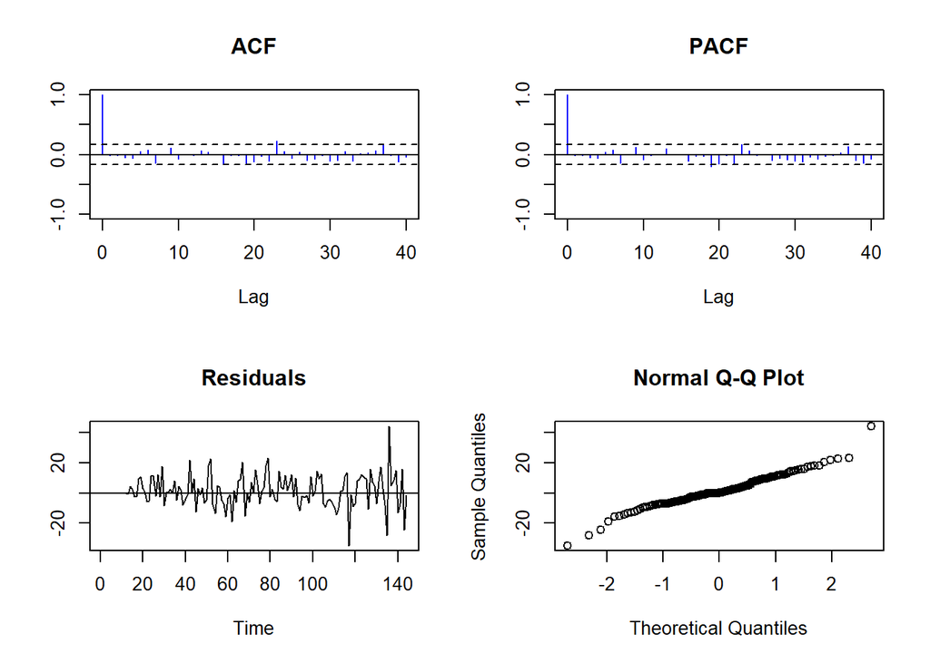

```r
# SARIMA (4,1,2)x(1,1,2)12
fit4 = arima(airpass,
             order = c(4,1,2),
             seasonal = list(order=c(1,1,2), period=12))
test(fit4$residuals)
```

```r
confint(fit4)
```

```
           2.5 %     97.5 %
ar1  -0.53547489 -0.1798493
ar2   0.61645404  1.0200446
ar3   0.03863969  0.4215009
ar4  -0.29461575  0.0726325
ma1  -0.07180368  0.1241729
ma2  -1.07015800 -0.8774339
sar1 -1.84219098  0.1465076
sma1 -0.34797752  1.8538719
sma2 -0.28678737  0.3101808
```

FTR the null hypothesis. The model is stationary.

```
Null hypothesis: Residuals are iid noise.
Test                        Distribution Statistic   p-value
Ljung-Box Q                Q ~ chisq(20)     21.07     0.393
McLeod-Li Q                Q ~ chisq(20)     24.87    0.2064
Turning points T     (T-94.7)/5 ~ N(0,1)        85    0.0545
Diff signs S       (S-71.5)/3.5 ~ N(0,1)        72    0.8856
Rank P           (P-5148)/289.5 ~ N(0,1)      5126    0.9394
```

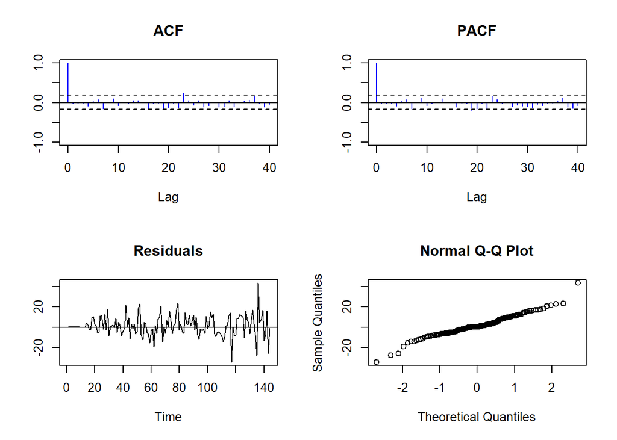

```r
# SARIMA (5,1,2)x(1,1,1)12
fit5 = arima(airpass,
             order = c(5,1,2),
             seasonal = list(order=c(1,1,1), period=12))
test(fit5$residuals)
```

```r
confint(fit5)
```

```
           2.5 %      97.5 %
ar1  -0.52976336 -0.17018375
ar2   0.61457802  1.00797386
ar3  -0.03370882  0.43560494
ar4  -0.28891401  0.09409092
ar5  -0.14373892  0.21644143
ma1  -0.08099307  0.13004191
ma2  -1.07921076 -0.87173731
sar1 -1.44263380 -0.29512966
sma1  0.04120566  1.50811916
```

```
Null hypothesis: Residuals are iid noise.
Test                        Distribution Statistic   p-value
Ljung-Box Q                Q ~ chisq(20)      9.05    0.9823
McLeod-Li Q                Q ~ chisq(20)     23.94    0.2449
Turning points T     (T-94.7)/5 ~ N(0,1)        89    0.2597
Diff signs S       (S-71.5)/3.5 ~ N(0,1)        74     0.472
Rank P           (P-5148)/289.5 ~ N(0,1)      5079    0.8116
```

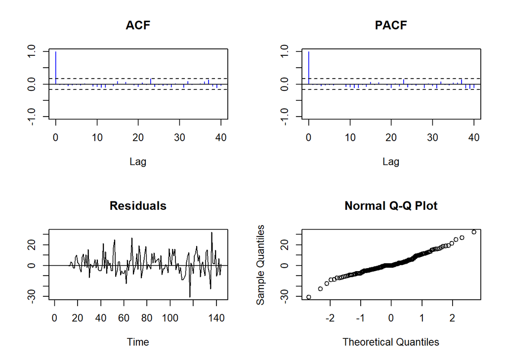

```r
# SARIMA (13,1,2)x(1,1,0)12
fit6 = arima(airpass,
             order = c(13,1,2),
             seasonal = list(order=c(1,1,0), period=12))
test(fit6$residuals)
```

```r
confint(fit6)
```

```
           2.5 %      97.5 %
ar1   1.00216967  1.52240124
ar2  -0.48551723  0.14231504
ar3  -0.48003983  0.04114070
ar4  -0.32654223  0.16742340
ar5   0.06652883  0.57670407
ar6  -0.44289862  0.07444483
ar7  -0.41956788  0.08878317
ar8  -0.13836908  0.37793874
ar9   0.01375309  0.52298039
ar10 -0.77444923 -0.22425432
ar11  0.10913118  0.70485520
ar12 -0.09665001  0.54836081
ar13 -0.60996411 -0.21277974
ma1  -1.95070232 -1.40631418
ma2   0.43744407  0.96280250
sar1 -0.78861794 -0.42974813
```

FTR the null hypothesis. The model is stationary.

## SARIMA Comparison

```r
# Comparison
AIC.values = c(
  autoModel = bestmodel$aic,
  fit1 = fit1$aic,
  fit2 = fit2$aic,
  fit3 = fit3$aic,
  fit4 = fit4$aic,
  fit5 = fit5$aic,
  fit6 = fit6$aic
)
AIC.values
```

```
autoModel      fit1      fit2      fit3      fit4      fit5      fit6
 1356.150  1022.300  1018.233  1019.547  1020.227  1020.076  1012.429
```

## SARIMA Equation

```r
round(fit2$coef, digits = 3)
```

```
   ar1    ar2    ar3    ar4    ma1    ma2   sar1   sma1
-0.357  0.817  0.229 -0.110  0.026 -0.974 -0.869  0.771
```

$$(1-0.357B+0.817B^2+0.229^3-0.110B^4)(1-B)(1-B^{12})X_t$$

$$(1+0.026B-0.974B^2)Z_t$$

$$\Phi=-0.869 \quad \Theta=0.771$$

$$Z_t \sim WN(0,116.9)$$

```r
round(fit6$coef, digits = 3)
```

```
   ar1    ar2    ar3    ar4    ar5    ar6    ar7    ar8    ar9   ar10   ar11
 1.262 -0.172 -0.219 -0.080  0.322 -0.184 -0.165  0.120  0.268 -0.499  0.407
  ar12   ar13    ma1    ma2   sar1
 0.226 -0.411 -1.679  0.700 -0.609
```

$$(1+1.262B -0.172B^2 -0.219^3 -0.080B^4 +0.322B^5 -0.184B^6 -0.165B^7 +0.120B^8 +0.268B^9 -0.499B^{10} + 0.407B^{11} +0.226B^{12} - 0.411B^{13}) (1-B) (1-B^{12}) X_t$$

$$(1-1.679B + 0.700B^2) Z_t$$

$$\Phi=-0.609 \quad \theta=0$$

$$Z_t \sim WN(0,97.34)$$

# Wine

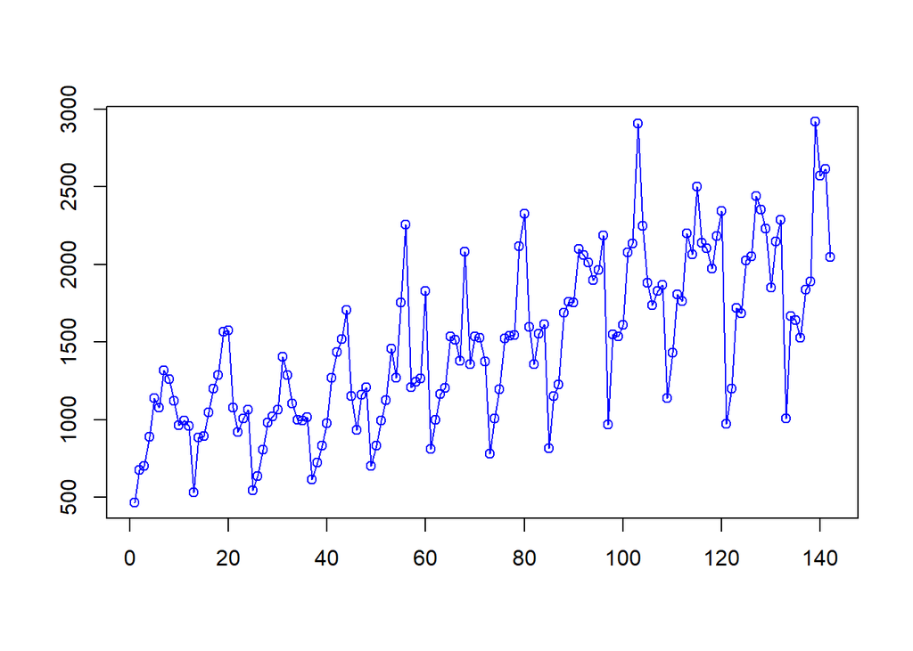

```r
plotc(wine)
```

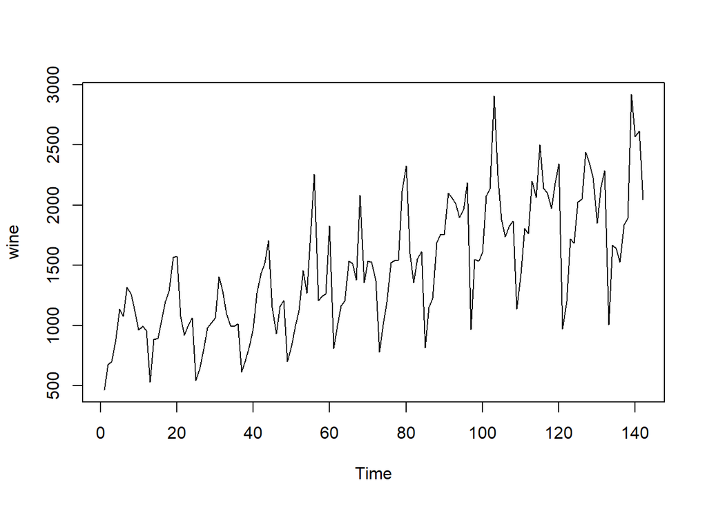

```r
plot.ts(wine)
```

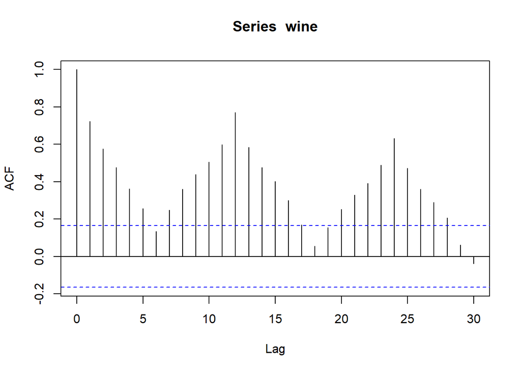

```r
# ACF, PACF
acf(wine, lag.max = 30)
```

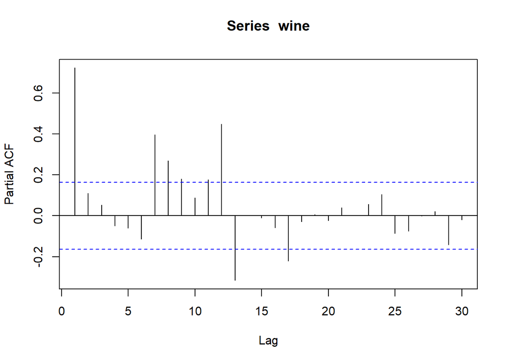

```r
pacf(wine, lag.max = 30)
```

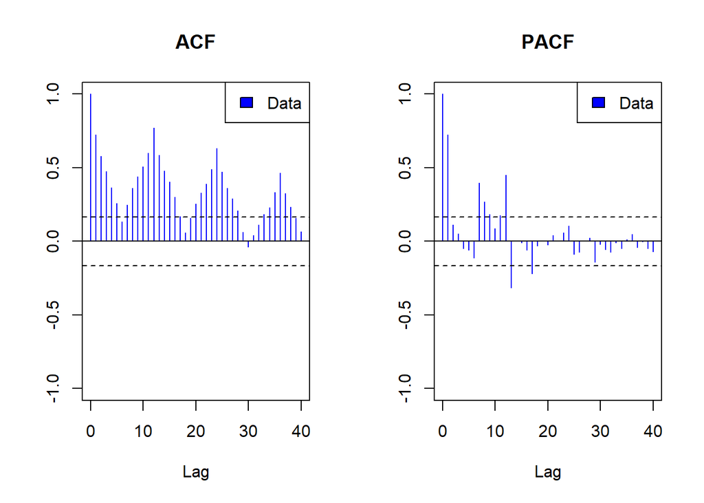

```r
plota(wine)
```

## Comments on Trend, Seasonality, Variance

The Wine time series has upward trend, seasonality (d=12) based on ACF, and variance change.

The Wine model:

$$X_t = m_t + s_t + Y_t$$

## Power Transformation

```r
# Variance change transformation
lambda = powerTransform(wine)
lambda$roundlam
```

```
wine
 0.5
```

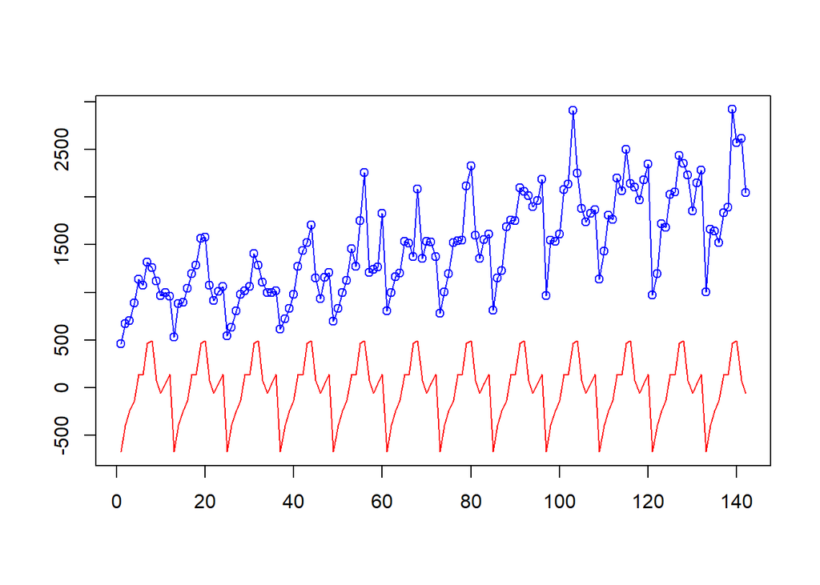

```r
# Seasonality
wine_season = season(wine, d=12)
plotc(wine, wine_season)
```

## Differencing Operator

By Elimination, we have the following:

```
Null hypothesis: Residuals are iid noise.
Test                        Distribution Statistic   p-value
Ljung-Box Q                Q ~ chisq(20)     64.27         0 *
McLeod-Li Q                Q ~ chisq(20)     28.49    0.0984
Turning points T   (T-84.7)/4.8 ~ N(0,1)        86    0.7792
Diff signs S         (S-64)/3.3 ~ N(0,1)        63    0.7613
Rank P           (P-4128)/245.6 ~ N(0,1)      4114    0.9545
```

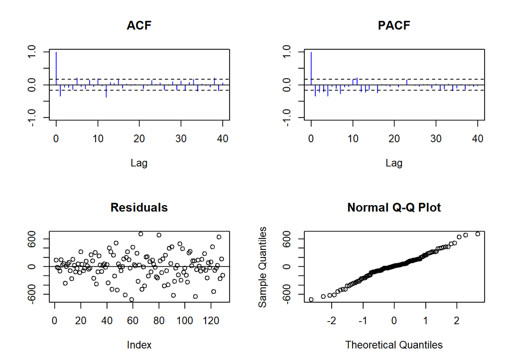

```r
# Eliminate components using Differencing Operator
wine_diff = c("diff", 12, "diff", 1)
wine_r_diff = Resid(wine, wine_diff)
test(wine_r_diff)
```

Reject the IID null hypothesis.

## Test Stationary

```r
adf.test(wine_r_diff)
```

```
Augmented Dickey-Fuller Test
alternative: stationary

Type 1: no drift no trend
     lag    ADF p.value
[1,]   0 -16.07    0.01
[2,]   1 -11.46    0.01
[3,]   2  -9.84    0.01
[4,]   3 -10.46    0.01
[5,]   4  -7.84    0.01
Type 2: with drift no trend
     lag    ADF p.value
[1,]   0 -16.00    0.01
[2,]   1 -11.42    0.01
[3,]   2  -9.80    0.01
[4,]   3 -10.42    0.01
[5,]   4  -7.81    0.01
Type 3: with drift and trend
     lag    ADF p.value
[1,]   0 -15.94    0.01
[2,]   1 -11.38    0.01
[3,]   2  -9.77    0.01
[4,]   3 -10.38    0.01
[5,]   4  -7.79    0.01
----
Note: in fact, p.value = 0.01 means p.value <= 0.01
```

## SARIMA Model

### Based on the PACF

p = 0,1,7,8,9,11,12,13,17

P = 0,1,2

### Based on the ACF

q = 0:5, 7:16, 20:28

Q = 0,1,2

### Eliminate Trend and Season

d= 1

D = 1

```
Null hypothesis: Residuals are iid noise.
Test                        Distribution Statistic   p-value
Ljung-Box Q                Q ~ chisq(20)     19.38    0.4972
McLeod-Li Q                Q ~ chisq(20)     19.73    0.4746
Turning points T     (T-93.3)/5 ~ N(0,1)       101    0.1246
Diff signs S       (S-70.5)/3.5 ~ N(0,1)        70    0.8848
Rank P         (P-5005.5)/283.5 ~ N(0,1)      4885    0.6708
```

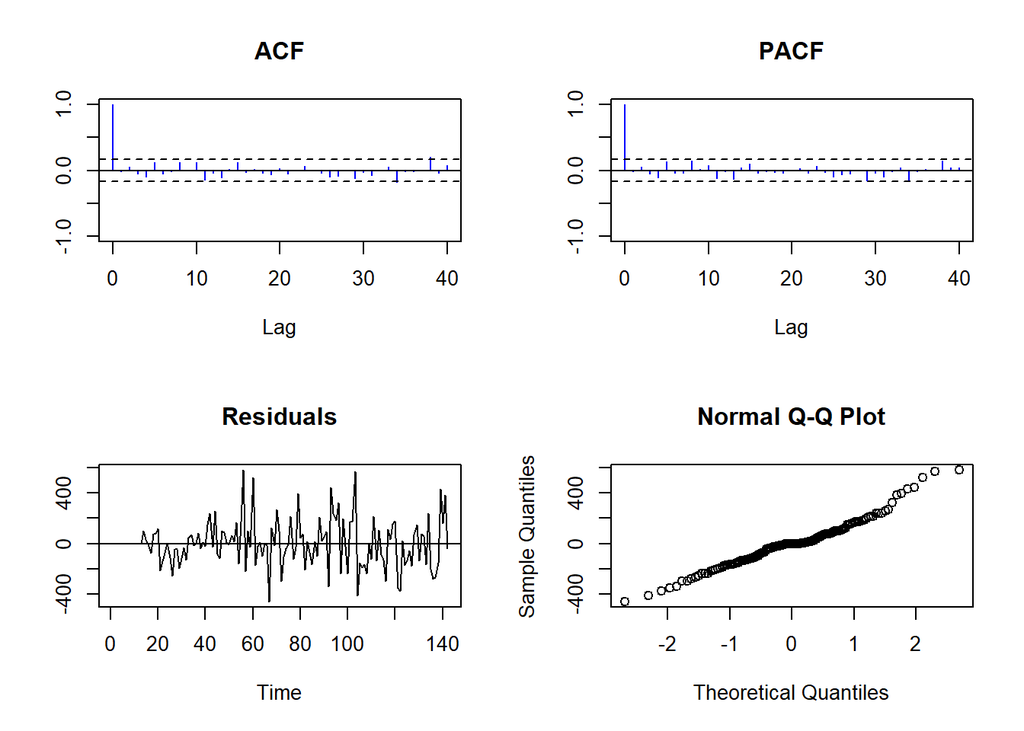

```r
# SARIMA (1,1,1)x(1,1,1)12
wine_fit1 = arima(wine,
             order = c(1,1,1),
             seasonal = list(order=c(1,1,1), period=12))
test(wine_fit1$residuals)
```

```r
confint(wine_fit1)
```

```
           2.5 %     97.5 %
ar1  -0.08054636  0.3731469
ma1  -1.00545417 -0.7580647
sar1 -0.45963801  0.2797869
sma1 -0.85549962 -0.1594213
```

FTR the null hypothesis. The model is stationary.

### Auto-Fit

```r
# Auto fit
wine_bestmodel = auto.arima(wine, trace = T, seasonal = T)
```

```
 ARIMA(2,1,2) with drift         : Inf
 ARIMA(0,1,0) with drift         : 2081.891
 ARIMA(1,1,0) with drift         : 2074.393
 ARIMA(0,1,1) with drift         : 2070.92
 ARIMA(0,1,0)                    : 2079.954
 ARIMA(1,1,1) with drift         : Inf
 ARIMA(0,1,2) with drift         : Inf
 ARIMA(1,1,2) with drift         : Inf
 ARIMA(0,1,1)                    : 2069.189
 ARIMA(1,1,1)                    : 2054.062
 ARIMA(1,1,0)                    : 2072.529
 ARIMA(2,1,1)                    : 2056.171
 ARIMA(1,1,2)                    : 2056.172
 ARIMA(0,1,2)                    : 2060.494
 ARIMA(2,1,0)                    : 2070.799
 ARIMA(2,1,2)                    : 2058.094

 Best model: ARIMA(1,1,1)
```

```
Null hypothesis: Residuals are iid noise.
Test                        Distribution Statistic   p-value
Ljung-Box Q                Q ~ chisq(20)    158.18         0 *
McLeod-Li Q                Q ~ chisq(20)    132.57         0 *
Turning points T     (T-93.3)/5 ~ N(0,1)        89    0.3854
Diff signs S       (S-70.5)/3.5 ~ N(0,1)        73    0.4689
Rank P         (P-5005.5)/283.5 ~ N(0,1)      5168    0.5665
```

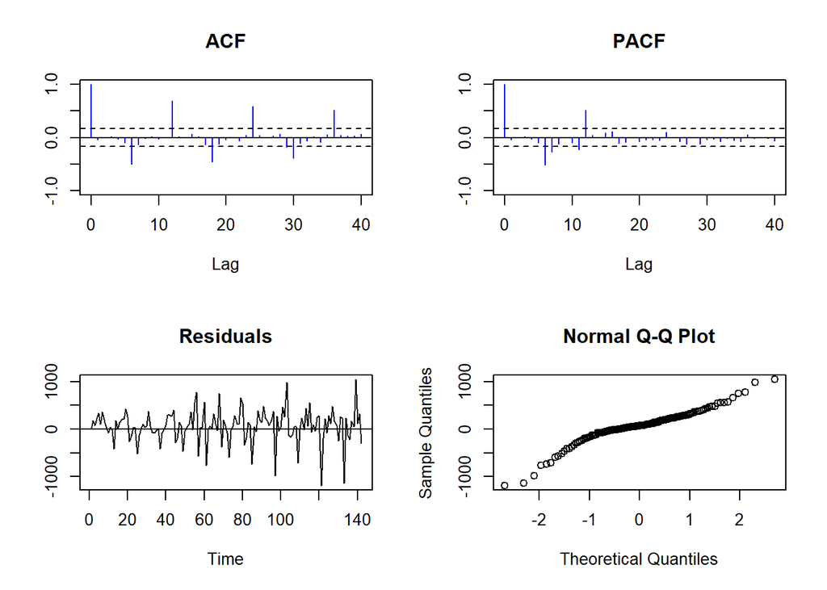

```r
test(wine_bestmodel$residuals)
```

Using the best model (1,1,1) to remove seasonality for stationary models.

```
Null hypothesis: Residuals are iid noise.
Test                        Distribution Statistic   p-value
Ljung-Box Q                Q ~ chisq(20)      19.3    0.5023
McLeod-Li Q                Q ~ chisq(20)     19.72    0.4757
Turning points T     (T-93.3)/5 ~ N(0,1)       101    0.1246
Diff signs S       (S-70.5)/3.5 ~ N(0,1)        70    0.8848
Rank P         (P-5005.5)/283.5 ~ N(0,1)      4901    0.7124
```

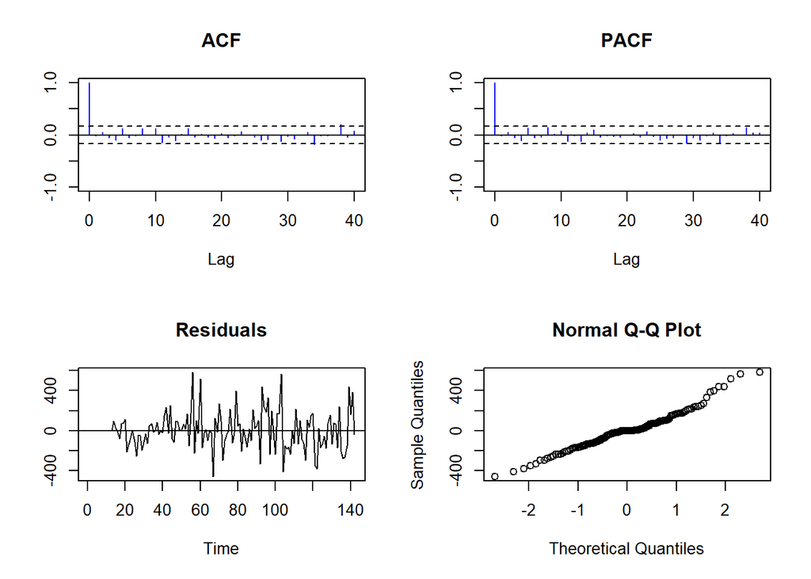

```r
# SARIMA (1,1,1)x(1,1,2)12
wine_fit2 = arima(wine,
             order = c(1,1,1),
             seasonal = list(order=c(1,1,2), period=12))
test(wine_fit2$residuals)
```

```r
confint(wine_fit2)
```

```
           2.5 %     97.5 %
ar1  -0.08133391  0.3717614
ma1  -1.00530635 -0.7563285
sar1 -1.62264880  1.0442604
sma1 -1.64805054  1.0270384
sma2 -0.90269210  0.6774487
```

FTR the null hypothesis. The time series model is stationary.

```
Null hypothesis: Residuals are iid noise.
Test                        Distribution Statistic   p-value
Ljung-Box Q                Q ~ chisq(20)     19.23    0.5072
McLeod-Li Q                Q ~ chisq(20)      18.9    0.5282
Turning points T     (T-93.3)/5 ~ N(0,1)       101    0.1246
Diff signs S       (S-70.5)/3.5 ~ N(0,1)        70    0.8848
Rank P         (P-5005.5)/283.5 ~ N(0,1)      4891    0.6863
```

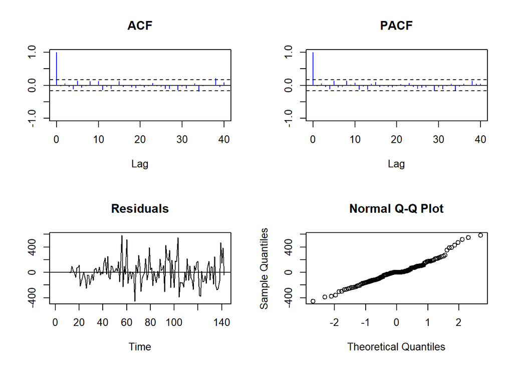

```r
# SARIMA (1,1,1)x(2,1,1)12
wine_fit3 = arima(wine,
             order = c(1,1,1),
             seasonal = list(order=c(2,1,1), period=12))
test(wine_fit3$residuals)
```

```r
confint(wine_fit3)
```

```
           2.5 %     97.5 %
ar1  -0.07413605  0.3728157
ma1  -1.00798506 -0.7550281
sar1 -0.48017271  0.6222910
sar2 -0.24523410  0.4662207
sma1 -1.20072591 -0.1400054
```

FTR the null hypothesis. The time series model is stationary.

```
Null hypothesis: Residuals are iid noise.
Test                        Distribution Statistic   p-value
Ljung-Box Q                Q ~ chisq(20)     22.36    0.3212
McLeod-Li Q                Q ~ chisq(20)     25.05    0.1995
Turning points T     (T-93.3)/5 ~ N(0,1)       101    0.1246
Diff signs S       (S-70.5)/3.5 ~ N(0,1)        68    0.4689
Rank P         (P-5005.5)/283.5 ~ N(0,1)      4904    0.7203
```

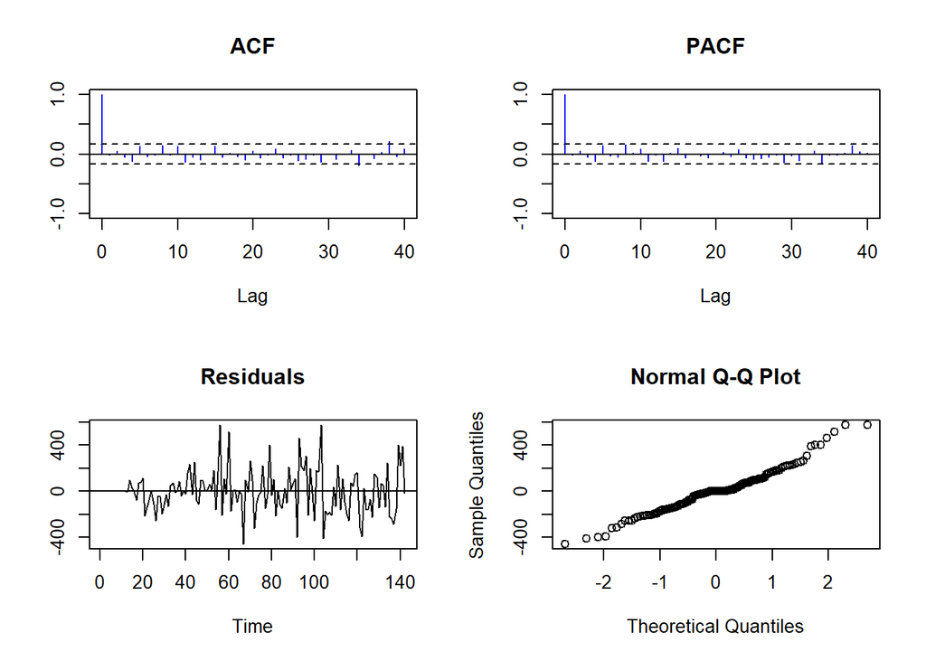

```r
# SARIMA (1,1,1)x(2,1,0)12
wine_fit4 = arima(wine,
             order = c(1,1,1),
             seasonal = list(order=c(2,1,0), period=12))
test(wine_fit4$residuals)
```

```r
confint(wine_fit4)
```

```
          2.5 %      97.5 %
ar1  -0.0867414  0.37292210
ma1  -1.0067230 -0.75022399
sar1 -0.7525116 -0.37294622
sar2 -0.3715881 -0.01263106
```

FTR the null hypothesis. The time series model is stationary.

```
Null hypothesis: Residuals are iid noise.
Test                        Distribution Statistic   p-value
Ljung-Box Q                Q ~ chisq(20)     19.34    0.4999
McLeod-Li Q                Q ~ chisq(20)      19.4    0.4959
Turning points T     (T-93.3)/5 ~ N(0,1)       101    0.1246
Diff signs S       (S-70.5)/3.5 ~ N(0,1)        70    0.8848
Rank P         (P-5005.5)/283.5 ~ N(0,1)      4888    0.6785
```

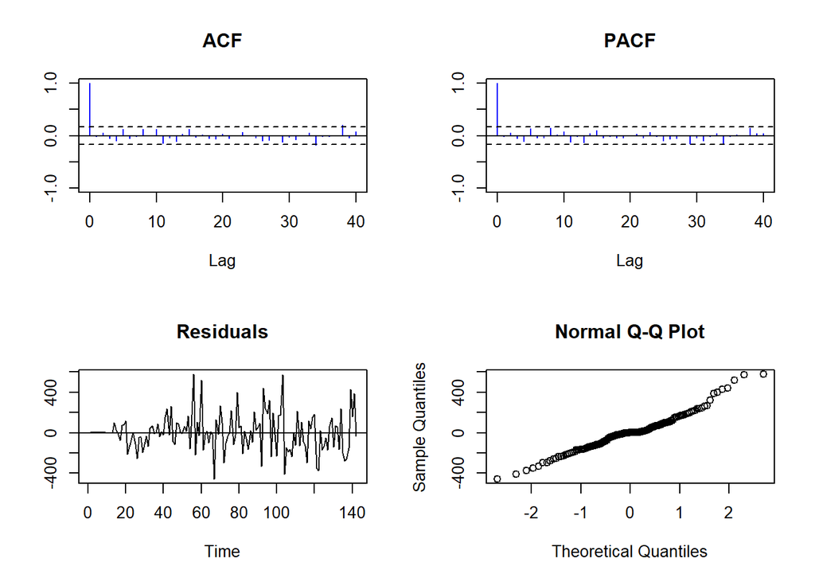

```r
# SARIMA (1,1,1)x(0,1,2)12
wine_fit5 = arima(wine,
             order = c(1,1,1),
             seasonal = list(order=c(0,1,2), period=12))
test(wine_fit5$residuals)
```

```r
confint(wine_fit5)
```

```
           2.5 %     97.5 %
ar1  -0.07493736  0.3739722
ma1  -1.00520578 -0.7619573
sma1 -0.78588778 -0.4003600
sma2 -0.14955242  0.2322775
```

FTR the null hypothesis. The time series model is stationary.

## SARIMA Comparison

```r
# Comparison
AIC.values = c(
  autoModel = bestmodel$aic,
  wine_fit1 = wine_fit1$aic,
  wine_fit2 = wine_fit2$aic,
  wine_fit3 = wine_fit3$aic,
  wine_fit4 = wine_fit4$aic,
  wine_fit5 = wine_fit5$aic
)
AIC.values
```

```
autoModel wine_fit1 wine_fit2 wine_fit3 wine_fit4 wine_fit5
 1356.150  1737.318  1739.252  1738.995  1738.857  1737.364
```

## SARIMA Equation

```r
round(coefficients(wine_fit1), digits = 3)
```

```
   ar1    ma1   sar1   sma1
 0.146 -0.882 -0.090 -0.507
```

$$(1+0.146B)(1-B)(1-B^{12})X_t$$

$$(1-0.882B)Z_t$$

$$\Phi=-0.090 \quad \Theta=-0.507$$

$$Z_t \sim WN(0,36447)$$

Another way to write the equation:

$$\phi(B)\Phi(B^{12}) (1-B^{12}) (1-B)^1 X_t = \theta(B)\Theta(B^{12}) Z_t \quad Z_t \sim WN(0, \sigma^2)$$

$$\phi=0.146, \quad \theta=-0.882, \quad \Phi=-0.090, \quad \Theta = -0.507$$

$$Z_t \sim WN(0,36447)$$